# Research Problem

5/2/2018

## Introduction

## Intuition

- While playing a videogame or learning how to drive, human beings are forced to *make decisions* and to *actively intervene* in the world.
- This active *decision-making* process modifies the state of the world, which allows us to learn about *causal relations* that hold in our environment
- We ask ourselves how an *intelligent agent* can acquire and *use causal knowledge* while engaging with its environment to achieve some task.
- The agent will interact with its environment and receive a feedback signal based on the actions taken by him, which will modify his cur- rent causal knowledge.

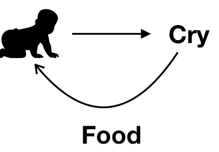

- Before the next step is taken, the current causal knowledge will be taken into account when choosing the next action together with the current value of each posible action.

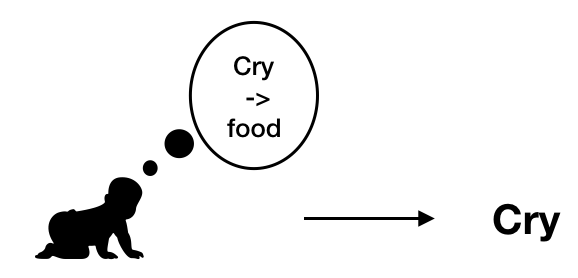

- This new action and its outcome will again modify the causal knowl- edge, which will improve the next action and so on.

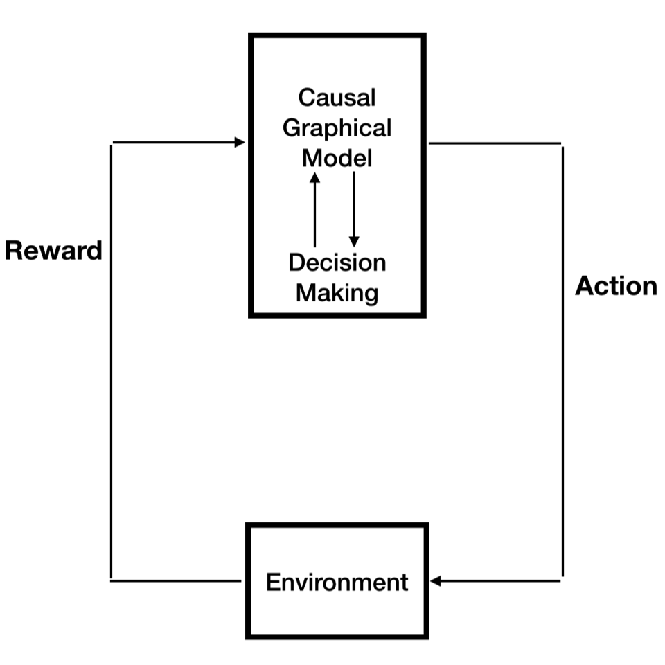

## Fields involved

- Learning by interaction.
- Sequential Decision Making.
- Causal learning.
- Bayesian inference.

## Research Problem

## Statement

- **Acquiring causal kwnoledge via interaction with the environment and using this knowledge to guide a decision-making process**
- Lay a bridge between Reinforcement Learning and Causal Learning: fundamental assumptions.
- Why reinforcement learning? Interventions are needed in order to acquire causal knowledge and RL provides an action-reaction interactive loop.

## Relevance

- Current RL methods are purely reactive.
- A lot of training time is required.
- Do not allow high-level reasoning.
- Learning causal structure will allow the agent to make better decisions because it will be able to consider consequences of his actions, and not only reacting to rewards.

## Feasibility

- We know how to learn by interaction (from Reinforcement Learning)
- We know that causal learning can be acquired in human beings through sequential decision making (from Computational Psychology).
- We know that *best action* can be selected from causal data (from sequential experimental design).
- Therefore, the elements exist and can be knitted together, although it will not be an easy task.
- The elements may exist, and although core ideas are shared in the fine details are far away between them.
- The Devil is in the details.

## Disclosure

- Causality as in (Pearl 2009) and (Spirtes, Glymour, and Scheines 2000)
- Other definitions of Causality exist.

## State of the Art

## Main groups and people

- Causality
  - Carnegie Mellon (Spirtes)
  - UC Los Angeles (Pearl)
  - MIT (Joshua Tenenbaum)
  - Max Planck Institute for Intelligent Systems (Schölkopf)
  - University of Copenhagen (Jonas Peters)
  - Edinburgh (Albrecht, Subramanian Ramamoorthy)
- Reinforcement Learning
  - Google DeepMind (David Silver, Alex Graves, V. Mnih, Shanahan, Garnelo)
  - Oxford (Nando De Freitas, Shimon Whiteson)
  - Cambridge (Ghahramani)
  - Alberta University (Richard Sutton, Csaba Szepesvári)
  - UC Berkeley (Pieter Abbeel)
  - Carnegie Mellon (Salakhutdinov)
  - Imperial College (Murray Shanahan, Marta Garnelo)
  - University College London (Peter Dayan, Watkins, Dawid)
  - Edinburgh (Craig Innes)
- Cognitive Science
  - Carnegie Mellon (David Danks)
  - MIT (Josh Tenenbaum)
  - UC Berkeley (Tom Griffiths)
  - Edinburgh University (Andy Clark)
  - Göttingen Institut für Psychologie (York Hagmayer)
  - Max Planck Institute for Human Development (Bjorn Meder)

## Outer Circle

- Causality

| Reference | Summary |
| --- | --- |
| (Holland 1986) | General review of different views on Causality |
| (Heckerman and Shachter 1995) | Decision-theoretic foundations for causal reasoning |
| (Spirtes, Glymour, and Scheines 2000) | Classic General book on Causality |
| (Joyce 1999) | Decision Theory and causal information |
| (Pearl 2009) | Book on Causality and Graphical models |
| (Koller and Friedman 2009) | Book on Probabilistic Graphical Models |

- Reinforcement Learning

| Reference | Summary |
| --- | --- |
| (Watkins and Dayan 1992) | Q-learning algorithm |
| (Sutton and Barto 1998) | Classic textbook on Reinforcement Learning |
| (Szepesvári 2010) | State of the Art Algorithms |
| (Otterlo and Wiering 2012) | General review |
| (Gershman 2015) | Reinforcement Learning in the Brain |
| (Li 2017) | Overview of Deep Reinforcement Learning |

- Cognitive aspects

| Reference | Summary |
| --- | --- |
| (Krynski and Tenenbaum 2007) | The role of causality in judgment under uncertainty |
| (Danks 2014) | Cognitive functions can be modelled as operations on graphical models |
| (Lake et al. 2017) | Conditions for machines to be considered intelligent: Causal learning is one |

## Middle Circle

| Reference | Summary |
| --- | --- |
| (Dawid 2002) | Influence Diagrams |
| (Eberhardt 2008) | Causal discovery as a game vs Nature |
| (Hagmayer and Sloman 2009) | Choices as interventions |
| (Wellen and Danks 2012) | learning causal structure in local maner via precition-error loop |

| Reference | Summary |
| --- | --- |
| (Mnih et al. 2013) | Introducing Deep Q-Network with Experience Replay |
| (Silver et al. 2014) | Deterministic Policy Gradients |
| (Lopez-Paz et al. 2015) | Discriminative data-driven framework for distinguishing direction of causality |
| (Schulman et al. 2015) | Trust Region Policy Optimization |
| (Goudet et al. 2017) | Functional Causal Models with Generative Neural Networks |
| (O’Donoghue et al. 2016) | Combining policy gradient and q-learning |

## Inner Circle

| Reference | Summary |
| --- | --- |
| (Hagmayer and Meder 2013) | How repeated decision making is guided by causal beliefs. |
| (Ortega and Braun 2014) | Thompson sampling to solve sequential adaptive control when policy is known. |
| (Alon et al. 2015) | When feedback is specified by graph, the graph structure controls the difficulty of learning. |
| (F. Lattimore, Lattimore, and Reid 2016) | Causal Bandits: Given a causal model, choose best intervention. |

| Reference | Summary |
| --- | --- |
| (S. Albrecht and Ramamoorthy 2016) | Exploiting Causality for Selective Belief Filtering in Dynamic {B}ayesian Networks |
| (Garnelo, Arulkumaran, and Shanahan 2016) | Reinforcement Learning framework that builds symbolic representation of environment. |
| (Innes et al. 2018) | An agent which, starting unaware of factors on which an optimal policy depends, learns optimal behaviour for single-stage decision problems via direct experience and advice from a domain expert. |
| (Pearl 2018) | Theoretical Impediments to Machine Learning With Seven Sparks from the Causal Revolution |

Albrecht, S.V., and S. Ramamoorthy. 2016. “Exploiting Causality for Selective Belief Filtering in Dynamic Bayesian Networks.” *Journal of Artificial Intelligence Research* 55. AI Access Foundation: 1135–78.

Alon, Noga, Nicolo Cesa-Bianchi, Ofer Dekel, and Tomer Koren. 2015. “Online Learning with Feedback Graphs: Beyond Bandits.” *arXiv Preprint arXiv:1502.07617*.

Danks, David. 2014. *Unifying the Mind: Cognitive Representations as Graphical Models*. Mit Press.

Dawid, A Philip. 2002. “Influence Diagrams for Causal Modelling and Inference.” *International Statistical Review* 70 (2). Wiley Online Library: 161–89.

Eberhardt, Frederick. 2008. “Causal Discovery as a Game.” In *Proceedings of the 2008th International Conference on Causality: Objectives and Assessment-Volume 6*, 87–96. JMLR. org.

Garnelo, Marta, Kai Arulkumaran, and Murray Shanahan. 2016. “Towards Deep Symbolic Reinforcement Learning.” *arXiv Preprint arXiv:1609.05518*.

Gershman, Samuel J. 2015. “Reinforcement Learning and Causal Models.” In *The Oxford Handbook of Causal Reasoning*.

Goudet, Olivier, Diviyan Kalainathan, Philippe Caillou, David Lopez-Paz, Isabelle Guyon, Michèle Sebag, Aris Tritas, and Paola Tubaro. 2017. “Learning Functional Causal Models with Generative Neural Networks.” *arXiv Preprint arXiv:1709.05321*.

Hagmayer, York, and Björn Meder. 2013. “Repeated Causal Decision Making.” *Journal of Experimental Psychology: Learning, Memory, and Cognition* 39 (1). American Psychological Association: 33.

Hagmayer, York, and Steven A Sloman. 2009. “Decision Makers Conceive of Their Choices as Interventions.” *Journal of Experimental Psychology: General* 138 (1). American Psychological Association: 22.

Heckerman, David, and Ross Shachter. 1995. “Decision-Theoretic Foundations for Causal Reasoning.” *Journal of Artificial Intelligence Research* 3: 405–30.

Holland, Paul W. 1986. “Statistics and Causal Inference.” *Journal of the American Statistical Association* 81 (396). Taylor & Francis Group: 945–60.

Innes, Craig, Alex Lascarides, Stefano V Albrecht, Subramanian Ramamoorthy, and Benjamin Rosman. 2018. “Reasoning About Unforeseen Possibilities During Policy Learning.” *arXiv Preprint arXiv:1801.03331*.

Joyce, James M. 1999. *The Foundations of Causal Decision Theory*. Cambridge University Press.

Koller, Daphne, and Nir Friedman. 2009. *Probabilistic Graphical Models: Principles and Techniques*. MIT press.

Krynski, Tevye R, and Joshua B Tenenbaum. 2007. “The Role of Causality in Judgment Under Uncertainty.” *Journal of Experimental Psychology: General* 136 (3). American Psychological Association: 430.

Lake, Brenden M, Tomer D Ullman, Joshua B Tenenbaum, and Samuel J Gershman. 2017. “Building Machines That Learn and Think Like People.” *Behavioral and Brain Sciences* 40. Cambridge University Press.

Lattimore, Finnian, Tor Lattimore, and Mark D Reid. 2016. “Causal Bandits: Learning Good Interventions via Causal Inference.” In *Advances in Neural Information Processing Systems 29*, edited by D. D. Lee, M. Sugiyama, U. V. Luxburg, I. Guyon, and R. Garnett, 1181–9. Curran Associates, Inc. http://papers.nips.cc/paper/6195-causal-bandits-learning-good-interventions-via-causal-inference.pdf.

Li, Yuxi. 2017. “Deep Reinforcement Learning: An Overview.” *arXiv Preprint arXiv:1701.07274*.

Lopez-Paz, David, Krikamol Muandet, Bernhard Schölkopf, and Iliya Tolstikhin. 2015. “Towards a Learning Theory of Cause-Effect Inference.” In *International Conference on Machine Learning*, 1452–61.

Mnih, Volodymyr, Koray Kavukcuoglu, David Silver, Alex Graves, Ioannis Antonoglou, Daan Wierstra, and Martin Riedmiller. 2013. “Playing Atari with Deep Reinforcement Learning.” *arXiv Preprint arXiv:1312.5602*.

Ortega, Pedro A, and Daniel A Braun. 2014. “Generalized Thompson Sampling for Sequential Decision-Making and Causal Inference.” *Complex Adaptive Systems Modeling* 2 (1). SpringerOpen: 2.

Otterlo, Martijn van, and Marco Wiering. 2012. “Reinforcement Learning and Markov Decision Processes.” In *Reinforcement Learning*, 3–42. Springer.

O’Donoghue, Brendan, Remi Munos, Koray Kavukcuoglu, and Volodymyr Mnih. 2016. “Pgq: Combining Policy Gradient and Q-Learning.” *arXiv Preprint arXiv:1611.01626*.

Pearl, Judea. 2009. *Causality*. Cambridge university press.

———. 2018. “Theoretical Impediments to Machine Learning with Seven Sparks from the Causal Revolution.” *arXiv Preprint arXiv:1801.04016*.

Schulman, John, Sergey Levine, Philipp Moritz, Michael I. Jordan, and Pieter Abbeel. 2015. “Trust Region Policy Optimization.” *CoRR* abs/1502.05477. http://arxiv.org/abs/1502.05477.

Silver, David, Guy Lever, Nicolas Heess, Thomas Degris, Daan Wierstra, and Martin Riedmiller. 2014. “Deterministic Policy Gradient Algorithms.” In *ICML*.

Spirtes, Peter, Clark N Glymour, and Richard Scheines. 2000. *Causation, Prediction, and Search*. MIT press.

Sutton, Richard S, and Andrew G Barto. 1998. *Reinforcement Learning: An Introduction*. Vol. 1. 1. MIT press Cambridge.

Szepesvári, Csaba. 2010. “Algorithms for Reinforcement Learning.” *Synthesis Lectures on Artificial Intelligence and Machine Learning* 4 (1). Morgan & Claypool Publishers: 1–103.

Watkins, Christopher JCH, and Peter Dayan. 1992. “Q-Learning.” *Machine Learning* 8 (3-4). Springer: 279–92.

Wellen, Sarah, and David Danks. 2012. “Learning Causal Structure Through Local Prediction-Error Learning.” In. Cognitive Science Society.